# simon-5505-05-slides

## Topics to be covered

- What you will learn
  - The FEV data set
  - Group means
  - Boxplots

## A quick note on a side topic, 1

- Creating “nice” tables is difficult
  - Round aggressively
  - Include title at top
  - Add explanatory material at bottom
  - Use descriptive row and column names
  - Use shading and/or borders

## A quick note on a side topic, 2

- Your options
  - Cut and paste into Word/Excel
    - Fast
    - WYSIWG
    - Revisions are painful
  - Create nice table in R
    - Slow
    - Every change requires a re-rendering
    - Revisions are easy

## A quick note on a side topic, 3

- Many R packages for nice tables
  - David Keyes. How to make beautiful tables in R. R for the rest of us blog, 2019-11-12. Available in [html format](https://rfortherestofus.com/2019/11/how-to-make-beautiful-tables-in-r).
- I will use gt library in this demo
  - Short for “Grammar of tables”
  - Uses a layered approach like ggplot2
- Use in this class is recommended, but not required.

## One warning about gt and similar packages

- Nice and re-usable are in conflict
  - Numbers converted to strings
  - Column names might be non-standard
    - Embedded blanks, special symbols
  - Merged cells destroy rectangular format

```r
tibble(x=1:4) |>
    gt() -> test01

names(test01)
```

```
 [1] "_data"          "_boxhead"       "_stub_df"       "_row_groups"
 [5] "_heading"       "_spanners"      "_stubhead"      "_footnotes"
 [9] "_source_notes"  "_formats"       "_substitutions" "_styles"
[13] "_summary"       "_options"       "_transforms"    "_locale"
[17] "_has_built"
```

## How do you characterize relationships?

- Between two continuous variables
  - Correlations and scatterplots
- Between two categorical variables
  - Crosstabulations
- Between a continuous variable and a categorical variable
  - Boxplots

## FEV data

Forced Expiratory Volume (FEV) in children. The data was collected in Boston in the 1970s.

## read in the FEV data set, glimpse

```
Rows: 654
Columns: 5
$ age   <dbl> 9, 8, 7, 9, 9, 8, 6, 6, 8, 9, 6, 8, 8, 8, 8, 7, 5, 6, 9, 9, 5, 5…
$ fev   <dbl> 1.708, 1.724, 1.720, 1.558, 1.895, 2.336, 1.919, 1.415, 1.987, 1…
$ ht    <dbl> 57.0, 67.5, 54.5, 53.0, 57.0, 61.0, 58.0, 56.0, 58.5, 60.0, 53.0…
$ sex   <dbl> 0, 0, 0, 1, 1, 0, 0, 0, 0, 0, 0, 1, 0, 1, 1, 1, 1, 0, 1, 1, 0, 0…
$ smoke <dbl> 0, 0, 0, 0, 0, 0, 0, 0, 0, 0, 0, 0, 0, 0, 0, 0, 0, 0, 0, 0, 0, 0…
```

## Verify that there are no missing values

[output not shown]

## Create factors

```
pulmonary |>
  mutate(smoke=factor(
    smoke,
    levels=0:1,
    labels=c("nonsmoker", "smoker"))) |>
  mutate(sex=factor(
    sex,
    levels=0:1,
    labels=c("female", "male"))) -> pulmonary_1
```

## Summary for continuous variables: age

[output not shown]

## Summary for continuous variables: fev

[output not shown]

## Summary for continuous variables: ht

[output not shown]

## Summary for categorical variables: sex

[output not shown]

## Summary for categorical variables: smoke

[output not shown]

## Break #1

- What you have learned
  - The FEV data set
- What’s coming next
  - Group means

## The group_by statement

- group_by creates separate analysis groups
  - Similar to split files (SPSS), by statement (SAS)
  - You create groups using one or more categorical variables
  - All further work done separately on each group

## Hypothetical data

```
# A tibble: 12 × 3
   intervention gender   age
   <chr>        <chr>  <dbl>
 1 c            F          6
 2 c            M          4
 3 c            F          7
 4 c            M          9
 5 t            F          6
 6 t            M          3
 7 t            F          5
 8 t            M          8
 9 t            F          4
10 t            M          7
11 t            F          6
12 t            M          2
```

## Using mutate with group_by

```r
hypo_4 |>
  count(intervention, gender) |>
  mutate(total=sum(n))
```

```
# A tibble: 4 × 4
  intervention gender     n total
  <chr>        <chr>  <int> <int>
1 c            F          2    12
2 c            M          2    12
3 t            F          4    12
4 t            M          4    12
```

```r
hypo_4 |>
  count(intervention, gender) |>
  group_by(intervention) |>
  mutate(total=sum(n))
```

```
# A tibble: 4 × 4
# Groups:   intervention [2]
  intervention gender     n total
  <chr>        <chr>  <int> <int>
1 c            F          2     4
2 c            M          2     4
3 t            F          4     8
4 t            M          4     8
```

## Using summarize with group_by

```r
hypo_4 |>
  summarize(
    age_mean=mean(age),
    age_sd=sd(age),
    n=n())
```

```
# A tibble: 1 × 3
  age_mean age_sd     n
     <dbl>  <dbl> <int>
1     5.58   2.07    12
```

```r
hypo_4 |>
  group_by(intervention) |>
  summarize(
    age_mean=mean(age),
    age_sd=sd(age),
    n=n())
```

```
# A tibble: 2 × 4
  intervention age_mean age_sd     n
  <chr>           <dbl>  <dbl> <int>
1 c                6.5    2.08     4
2 t                5.12   2.03     8
```

## Slice, 1

```r
hypo_4 |>
  slice_min(age)
```

```
# A tibble: 1 × 3
  intervention gender   age
  <chr>        <chr>  <dbl>
1 t            M          2
```

```r
hypo_4 |>
  group_by(intervention) |>
  slice_min(age)
```

```
# A tibble: 2 × 3
# Groups:   intervention [2]
  intervention gender   age
  <chr>        <chr>  <dbl>
1 c            M          4
2 t            M          2
```

## Slice, 2

```r
hypo_4 |>
  slice_sample(n=4)
```

```
# A tibble: 4 × 3
  intervention gender   age
  <chr>        <chr>  <dbl>
1 t            F          6
2 t            M          7
3 c            M          9
4 c            F          7
```

```r
hypo_4 |>
  group_by(intervention) |>
  slice_sample(n=2)
```

```
# A tibble: 4 × 3
# Groups:   intervention [2]
  intervention gender   age
  <chr>        <chr>  <dbl>
1 c            F          6
2 c            F          7
3 t            F          6
4 t            M          8
```

## Side effects of group_by

- Converts tibble or data frame to grouped tibble.
  - Some older R functions cannot work with grouped tibble
  - Use the ungroup function

## Be careful with group_by on two categorical variables, 1

```r
hypo_4 |>
  group_by(intervention, gender) |>
  summarize(
    age_mean=mean(age),
    age_sd=sd(age),
    n=n()) |>
  mutate(total=sum(n))
```

```
# A tibble: 4 × 6
# Groups:   intervention [2]
  intervention gender age_mean age_sd     n total
  <chr>        <chr>     <dbl>  <dbl> <int> <int>
1 c            F          6.5   0.707     2     4
2 c            M          6.5   3.54      2     4
3 t            F          5.25  0.957     4     8
4 t            M          5     2.94      4     8
```

## Be careful with group_by on two categorical variables, 2

```r
hypo_4 |>
  group_by(intervention, gender) |>
  summarize(
    age_mean=mean(age),
    age_sd=sd(age),
    n=n(),
    .groups="drop") |>
  mutate(total=sum(n))
```

```
# A tibble: 4 × 6
  intervention gender age_mean age_sd     n total
  <chr>        <chr>     <dbl>  <dbl> <int> <int>
1 c            F          6.5   0.707     2    12
2 c            M          6.5   3.54      2    12
3 t            F          5.25  0.957     4    12
4 t            M          5     2.94      4    12
```

## Break #2

- What you have learned
  - Group means
- What’s coming next
  - Boxplots

## How to show relationships

- Two continuous variables
  - Scatterplot
- Two categorical variables
  - Crosstabulation
- One categorical and one contnuous variable
  - Boxplots

## Boxplots, 1

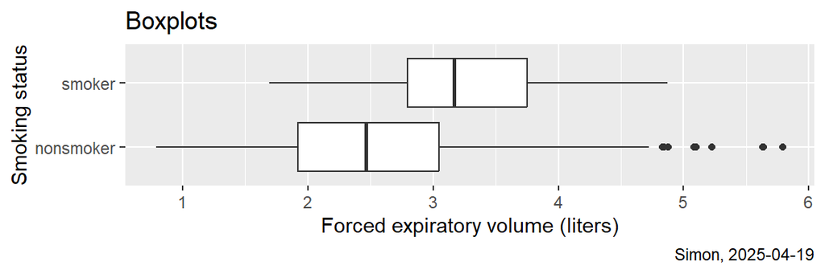

## Illustration of a boxplot

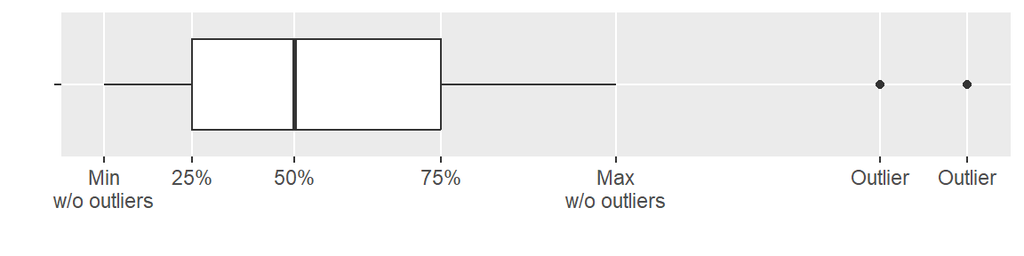

## Clustered boxplots, 1

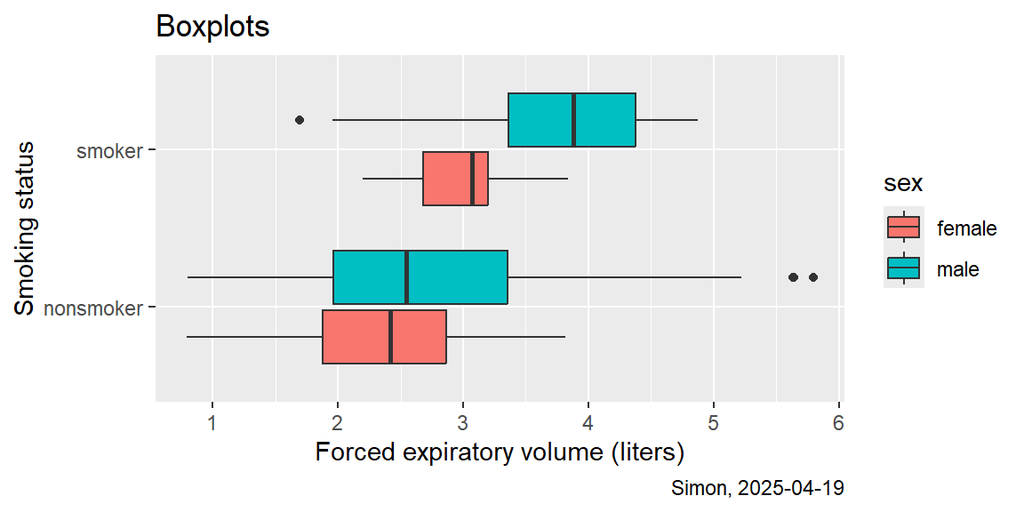

## Clustered boxplots, 2

[figure not shown]

## Summary

- What you have learned
  - The FEV data set
  - Group means
  - Boxplots